# Social Resilience Notebook

This is an [R Markdown](http://rmarkdown.rstudio.com) Notebook for preliminary Social Resilience analyses.

We begin by examining basic statistics for parcels in Davidson County.

```r
#setwd('C:/Users/nelsonks/Box Sync/Kate_Kevona/NashvilleFloodData')
#setwd('E:/kate/Box Sync/Kate_Kevona/NashvilleFloodData')
wd<- getwd()

years<-seq(2002,2016)
n<-length(years)

for (i in 1:n){

  assign( paste0("p",years[i],"_dat"), readRDS(paste0(wd,"/data/","parceldata",years[i],".RDS")))
  name<-get(paste0("p",years[i],"_dat"))

  # hist(name$SALE_PRICE[name$SALE_PRICE<=2000000],
  #  main=paste("Histogram of Property Sale Prices in",years[i]), xlab="Sale Price")

}
```

```r
# #change the name of columns to be consistent with other years
# p2002_dat$SALE_PRICE<-p2002_dat$PRICE
# p2002_dat$TOTAL_APPR<-p2002_dat$TOTLAPPR
# p2002_dat$LAND_USE<-p2002_dat$LANDUSE
# p2002_dat$SALE_PRICE<-p2002_dat$PRICE
# p2002_dat$DU_COUNT<-p2002_dat$DWELLUNITS
# p2003_dat$DU_COUNT<-p2003_dat$OCC_DWLGS
# p2004_dat$DU_COUNT<-p2004_dat$OCC_DWLGS
# p2005_dat$DU_COUNT<-p2005_dat$OCC_DWLGS
# p2006_dat$DU_COUNT<-NA
# p2016_dat$DU_COUNT<-p2016_dat$DUCount
# p2002_dat$LA_SQ_FT<-p2002_dat$FLOORSPACE
# p2006_dat$LA_SQ_FT<-NA
# p2016_dat$LA_SQ_FT<-p2016_dat$FinishArea
# p2016_dat$LAND_USE<-p2016_dat$LUCode
# p2016_dat$TOTAL_APPR<-p2016_dat$TotlAppr
# p2016_dat$SALE_PRICE<-p2016_dat$SalePrice
#
# #add a year column
# for (i in 1:n){
#
#   name<-get(paste0("p",years[i],"_dat"))
#   name$Year<-years[i]
#   assign(paste0("p",years[i],"_dat.b"), name)
# }
# i=1
# #format data side-by-side, add, columns for assessed value, description,quality, and age
# SALES<-merge.data.frame(get(paste0("p",years[i],"_dat.b"))[,c("STANPAR","SALE_PRICE","Year","TOTAL_APPR", "LAND_USE","LA_SQ_FT","DU_COUNT")],get(paste0("p",years[i+1],"_dat.b"))[,c("STANPAR","SALE_PRICE","Year","TOTAL_APPR", "LAND_USE","LA_SQ_FT","DU_COUNT")],by=c("STANPAR"))
# SALES<-merge.data.frame(SALES,get(paste0("p",years[i+2],"_dat.b"))[,c("STANPAR","SALE_PRICE","Year","TOTAL_APPR", "LAND_USE","LA_SQ_FT","DU_COUNT")],by=c("STANPAR"))
# SALES<-merge.data.frame(SALES,get(paste0("p",years[i+3],"_dat.b"))[,c("STANPAR","SALE_PRICE","Year","TOTAL_APPR", "LAND_USE","LA_SQ_FT","DU_COUNT")],by=c("STANPAR"))
# SALES<-merge.data.frame(SALES,get(paste0("p",years[i+4],"_dat.b"))[,c("STANPAR","SALE_PRICE","Year","TOTAL_APPR", "LAND_USE","LA_SQ_FT","DU_COUNT")],by=c("STANPAR"))
# SALES<-merge.data.frame(SALES,get(paste0("p",years[i+5],"_dat.b"))[,c("STANPAR","SALE_PRICE","Year","TOTAL_APPR", "LAND_USE","LA_SQ_FT","DU_COUNT")],by=c("STANPAR"))
# SALES<-merge.data.frame(SALES,get(paste0("p",years[i+6],"_dat.b"))[,c("STANPAR","SALE_PRICE","Year","TOTAL_APPR", "LAND_USE","LA_SQ_FT","DU_COUNT")],by=c("STANPAR"))
# SALES<-merge.data.frame(SALES,get(paste0("p",years[i+7],"_dat.b"))[,c("STANPAR","SALE_PRICE","Year","TOTAL_APPR", "LAND_USE","LA_SQ_FT","DU_COUNT")],by=c("STANPAR"))
# SALES<-merge.data.frame(SALES,get(paste0("p",years[i+8],"_dat.b"))[,c("STANPAR","SALE_PRICE","Year","TOTAL_APPR", "LAND_USE","LA_SQ_FT","DU_COUNT")],by=c("STANPAR"))
# SALES<-merge.data.frame(SALES,get(paste0("p",years[i+9],"_dat.b"))[,c("STANPAR","SALE_PRICE","Year","TOTAL_APPR", "LAND_USE","LA_SQ_FT","DU_COUNT")],by=c("STANPAR"))
# SALES<-merge.data.frame(SALES,get(paste0("p",years[i+10],"_dat.b"))[,c("STANPAR","SALE_PRICE","Year","TOTAL_APPR", "LAND_USE","LA_SQ_FT","DU_COUNT")],by=c("STANPAR"))
# SALES<-merge.data.frame(SALES,get(paste0("p",years[i+11],"_dat.b"))[,c("STANPAR","SALE_PRICE","Year","TOTAL_APPR", "LAND_USE","LA_SQ_FT","DU_COUNT")],by=c("STANPAR"))
# SALES<-merge.data.frame(SALES,get(paste0("p",years[i+12],"_dat.b"))[,c("STANPAR","SALE_PRICE","Year","TOTAL_APPR", "LAND_USE","LA_SQ_FT","DU_COUNT")],by=c("STANPAR"))
# SALES<-merge.data.frame(SALES,get(paste0("p",years[i+13],"_dat.b"))[,c("STANPAR","SALE_PRICE","Year","TOTAL_APPR", "LAND_USE","LA_SQ_FT","DU_COUNT", "LAND_USE_D","PARCEL_DAT")],by=c("STANPAR"))
# SALES<-merge.data.frame(SALES,get(paste0("p",years[i+14],"_dat.b"))[,c("STANPAR","SALE_PRICE","Year","TOTAL_APPR", "LAND_USE","LA_SQ_FT","DU_COUNT")],by=c("STANPAR"))
#
# SALES_dup<-SALES #save a copy
#
# SALES<-SALES[ ,c(1,
#                  2,8,14,20,26,32,38,44,50,56,62,68,74,80,88,
#                  3,9,15,21,27,33,39,45,51,57,63,69,75,81,89,
#                  4,10,16,22,28,34,40,46,52,58,64,70,76,82,90,
#                  5,11,17,23,29,35,41,47,53,59,65,71,77,83,91,
#                  6,12,18,24,30,36,42,48,54,60,66,72,78,84,92,
#                  7,13,19,25,31,37,43,49,55,61,67,73,79,85,93,
#                  86,87)]
#
# colnames(SALES)<-c("STANPAR",paste0("SALES",years[i]),paste0("SALES",years[i+1]),paste0("SALES",years[i+2]),paste0("SALES",years[i+3]),paste0("SALES",years[i+4]),paste0("SALES",years[i+5]), paste0("SALES",years[i+6]), paste0("SALES",years[i+7]),paste0("SALES",years[i+8]), paste0("SALES",years[i+9]), paste0("SALES",years[i+10]), paste0("SALES",years[i+11]), paste0("SALES",years[i+12]), paste0("SALES",years[i+13]), paste0("SALES",years[i+14]),
#                    paste0(years[i]), paste0(years[i+1]),paste0(years[i+2]),paste0(years[i+3]),paste0(years[i+4]),paste0(years[i+5]),paste0(years[i+6]),paste0(years[i+7]),paste0(years[i+8]),paste0(years[i+9]),paste0(years[i+10]),paste0(years[i+11]),paste0(years[i+12]),paste0(years[i+13]),paste0(years[i+14]),
#                    paste0("TOTAL_APPR",years[i]),paste0("TOTAL_APPR",years[i+1]),paste0("TOTAL_APPR",years[i+2]),paste0("TOTAL_APPR",years[i+3]),paste0("TOTAL_APPR",years[i+4]),paste0("TOTAL_APPR",years[i+5]), paste0("TOTAL_APPR",years[i+6]), paste0("TOTAL_APPR",years[i+7]),paste0("TOTAL_APPR",years[i+8]), paste0("TOTAL_APPR",years[i+9]), paste0("TOTAL_APPR",years[i+10]), paste0("TOTAL_APPR",years[i+11]), paste0("TOTAL_APPR",years[i+12]), paste0("TOTAL_APPR",years[i+13]),paste0("TOTAL_APPR",years[i+14]),
#                    paste0("LAND_USE",years[i]),paste0("LAND_USE",years[i+1]),paste0("LAND_USE",years[i+2]),paste0("LAND_USE",years[i+3]),paste0("LAND_USE",years[i+4]),paste0("LAND_USE",years[i+5]), paste0("LAND_USE",years[i+6]), paste0("LAND_USE",years[i+7]),paste0("LAND_USE",years[i+8]), paste0("LAND_USE",years[i+9]), paste0("LAND_USE",years[i+10]), paste0("LAND_USE",years[i+11]), paste0("LAND_USE",years[i+12]), paste0("LAND_USE",years[i+13]),paste0("LAND_USE",years[i+14]),
#                    paste0("LA_SQ_FT",years[i]),paste0("LA_SQ_FT",years[i+1]),paste0("LA_SQ_FT",years[i+2]),paste0("LA_SQ_FT",years[i+3]),paste0("LA_SQ_FT",years[i+4]),paste0("LA_SQ_FT",years[i+5]), paste0("LA_SQ_FT",years[i+6]), paste0("LA_SQ_FT",years[i+7]),paste0("LA_SQ_FT",years[i+8]), paste0("LA_SQ_FT",years[i+9]), paste0("LA_SQ_FT",years[i+10]), paste0("LA_SQ_FT",years[i+11]), paste0("LA_SQ_FT",years[i+12]), paste0("LA_SQ_FT",years[i+13]),paste0("LA_SQ_FT",years[i+14]),
#                    paste0("DU_COUNT",years[i]),paste0("DU_COUNT",years[i+1]),paste0("DU_COUNT",years[i+2]),paste0("DU_COUNT",years[i+3]),paste0("DU_COUNT",years[i+4]),paste0("DU_COUNT",years[i+5]), paste0("DU_COUNT",years[i+6]), paste0("DU_COUNT",years[i+7]),paste0("DU_COUNT",years[i+8]), paste0("DU_COUNT",years[i+9]), paste0("DU_COUNT",years[i+10]), paste0("DU_COUNT",years[i+11]), paste0("DU_COUNT",years[i+12]), paste0("DU_COUNT",years[i+13]),paste0("DU_COUNT",years[i+14]),
#                     paste0("LAND_USE_D",years[i+13]), paste0("PARCEL_DAT",years[i+13]))
#
# #if i can i should do this seperately for proerty in USD and GSD (i think this is listed in the parcel data)
# SALES$tax2002<-SALES$TOTAL_APPR2002*.25/100*4.58
# SALES$tax2003<-as.numeric(SALES$TOTAL_APPR2003)*.25/100*4.58
# SALES$tax2004<-as.numeric(SALES$TOTAL_APPR2004)*.25/100*4.58
# SALES$tax2005<-as.numeric(SALES$TOTAL_APPR2005)*.25/100*4.69
# SALES$tax2006<-SALES$TOTAL_APPR2006*.25/100*4.69
# SALES$tax2007<-SALES$TOTAL_APPR2007*.25/100*4.69
# SALES$tax2008<-SALES$TOTAL_APPR2008*.25/100*4.69
# SALES$tax2009<-SALES$TOTAL_APPR2009*.25/100*4.13
# SALES$tax2010<-SALES$TOTAL_APPR2010*.25/100*4.13
# SALES$tax2011<-SALES$TOTAL_APPR2011*.25/100*4.13
# SALES$tax2012<-SALES$TOTAL_APPR2012*.25/100*4.66
# SALES$tax2013<-SALES$TOTAL_APPR2013*.25/100*4.516
# SALES$tax2014<-SALES$TOTAL_APPR2014*.25/100*4.516
# SALES$tax2015<-SALES$TOTAL_APPR2015*.25/100*4.516
# SALES$tax2016<-SALES$TOTAL_APPR2016*.25/100*4.516
#
#
# SALES$taxchange2003<-SALES$tax2003-SALES$tax2002
# SALES$taxchange2004<-SALES$tax2004-SALES$tax2003
# SALES$taxchange2005<-SALES$tax2005-SALES$tax2004
# SALES$taxchange2006<-SALES$tax2006-SALES$tax2005
# SALES$taxchange2007<-SALES$tax2007-SALES$tax2006
# SALES$taxchange2008<-SALES$tax2008-SALES$tax2007
# SALES$taxchange2009<-SALES$tax2009-SALES$tax2008
# SALES$taxchange2010<-SALES$tax2010-SALES$tax2009
# SALES$taxchange2011<-SALES$tax2011-SALES$tax2010
# SALES$taxchange2012<-SALES$tax2012-SALES$tax2011
# SALES$taxchange2013<-SALES$tax2013-SALES$tax2012
# SALES$taxchange2014<-SALES$tax2014-SALES$tax2013
# SALES$taxchange2015<-SALES$tax2015-SALES$tax2014
# SALES$taxchange2016<-SALES$tax2016-SALES$tax2015
#
# #determine if a new sale occured at location i in year j
# for (i in 1:length(SALES[,1])){
#
#   if (is.na(SALES[i,2])){
#
#         SALES[i,2]<-SALES[i,3]
#   }
#
#   for (j in 15:3){
#
#     if (SALES[i,j]!= SALES[i,j-1]){
#
#           SALES[i,j]<-SALES[i,j]
#
#   }else{
#     SALES[i,j]<-"NA"
#     }
#  }
# }
#
# saveRDS(SALES,"metrosales_plus2.RDS")
SALES<-readRDS(paste0(wd,"/metrosales_plus2.RDS"))
SALES_dup<-SALES

SALES$SALES2002[SALES$SALES2002==0]<-NA
SALES[SALES=="NA"]<-NA

#subset sales to residential parcels only
subset<-c(11,12,13,14,15,36,37,38,39,81,82,83,88,89)
SALES_sub<-SALES

SALES_sub$LAND_USE2002<-as.numeric(SALES_sub$LAND_USE2002)
SALES_sub$LAND_USE2003<-as.numeric(SALES_sub$LAND_USE2003)
SALES_sub$LAND_USE2004<-as.numeric(SALES_sub$LAND_USE2004)
SALES_sub$LAND_USE2005<-as.numeric(SALES_sub$LAND_USE2005)
SALES_sub$LAND_USE2006<-as.numeric(SALES_sub$LAND_USE2006)
SALES_sub$LAND_USE2007<-as.numeric(SALES_sub$LAND_USE2007)
SALES_sub$LAND_USE2008<-as.numeric(SALES_sub$LAND_USE2008)
```

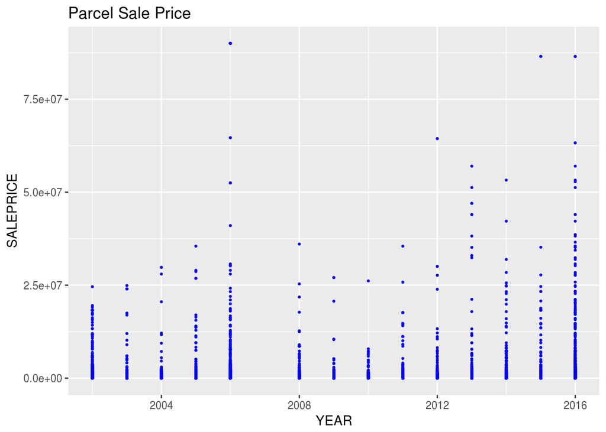

```r
SALES_sub$LAND_USE2009<-as.numeric(SALES_sub$LAND_USE2009)
SALES_sub$LAND_USE2010<-as.numeric(SALES_sub$LAND_USE2010)
SALES_sub$LAND_USE2011<-as.numeric(SALES_sub$LAND_USE2011)
SALES_sub$LAND_USE2012<-as.numeric(SALES_sub$LAND_USE2012)
SALES_sub$LAND_USE2013<-as.numeric(SALES_sub$LAND_USE2013)
SALES_sub$LAND_USE2014<-as.numeric(SALES_sub$LAND_USE2014)
SALES_sub$LAND_USE2015<-as.numeric(SALES_sub$LAND_USE2015)
SALES_sub$LAND_USE2016<-as.numeric(SALES_sub$LAND_USE2016)

#make sales of non-residential parcels NA
'%!in%' <- function(x,y)!('%in%'(x,y)) #make a "not in" function

SALES_sub$SALES2002[SALES_sub$LAND_USE2002 %!in% (subset)]<-NA
SALES_sub$SALES2003[SALES_sub$LAND_USE2003 %!in% (subset)]<-NA
SALES_sub$SALES2004[SALES_sub$LAND_USE2004 %!in% (subset)]<-NA
SALES_sub$SALES2005[SALES_sub$LAND_USE2005 %!in% (subset)]<-NA
SALES_sub$SALES2006[SALES_sub$LAND_USE2006 %!in% (subset)]<-NA
SALES_sub$SALES2007[SALES_sub$LAND_USE2007 %!in% (subset)]<-NA
SALES_sub$SALES2008[SALES_sub$LAND_USE2008 %!in% (subset)]<-NA
SALES_sub$SALES2009[SALES_sub$LAND_USE2009 %!in% (subset)]<-NA
SALES_sub$SALES2010[SALES_sub$LAND_USE2010 %!in% (subset)]<-NA
SALES_sub$SALES2011[SALES_sub$LAND_USE2011 %!in% (subset)]<-NA
SALES_sub$SALES2012[SALES_sub$LAND_USE2012 %!in% (subset)]<-NA
SALES_sub$SALES2013[SALES_sub$LAND_USE2013 %!in% (subset)]<-NA
SALES_sub$SALES2014[SALES_sub$LAND_USE2014 %!in% (subset)]<-NA
SALES_sub$SALES2015[SALES_sub$LAND_USE2015 %!in% (subset)]<-NA
SALES_sub$SALES2016[SALES_sub$LAND_USE2016 %!in% (subset)]<-NA

#build a time series of actual sales
# ts<-as.data.frame(c(SALES_sub[ ,2],SALES_sub[ ,3],SALES_sub[ ,4],SALES_sub[ ,5],SALES_sub[ ,6],SALES_sub[ ,7],SALES_sub[ ,8],SALES_sub[ ,9],SALES_sub[ ,10],SALES_sub[ ,11],SALES_sub[ ,12],SALES_sub[ ,13],SALES_sub[ ,14],SALES_sub[ ,15]))
# colnames(ts)<-c("SALEPRICE")
# ts$YEAR<-c(SALES_sub[ ,16],SALES_sub[ ,17],SALES_sub[ ,18],SALES_sub[ ,19],SALES_sub[ ,20],SALES_sub[ ,21],SALES_sub[ ,22],SALES_sub[ ,23],SALES_sub[ ,24],SALES_sub[ ,25],SALES_sub[ ,26],SALES_sub[ ,27],SALES_sub[ ,28],SALES_sub[ ,29])
# ts$SALEPRICE<-as.numeric(as.character(ts$SALEPRICE))

SALES_sub$taxchange2002<-NA

ts_full<-as.data.frame(cbind(c(SALES_sub[ ,2],SALES_sub[ ,3],SALES_sub[ ,4],SALES_sub[ ,5],SALES_sub[ ,6],SALES_sub[ ,7],SALES_sub[ ,8],SALES_sub[ ,9],SALES_sub[ ,10],SALES_sub[ ,11],SALES_sub[ ,12],SALES_sub[ ,13],SALES_sub[ ,14],SALES_sub[ ,15],SALES_sub[ ,16]),

                       c(SALES_sub[ ,17],SALES_sub[ ,18],SALES_sub[ ,19],SALES_sub[ ,20],SALES_sub[ ,21],SALES_sub[ ,21],SALES_sub[ ,23],SALES_sub[ ,24],SALES_sub[ ,25],SALES_sub[ ,26],SALES_sub[ ,27],SALES_sub[ ,28],SALES_sub[ ,29],SALES_sub[ ,30],SALES_sub[ ,31]),

                       c(SALES_sub[ ,32],SALES_sub[ ,33],SALES_sub[ ,34],SALES_sub[ ,35],SALES_sub[ ,36],SALES_sub[ ,37],SALES_sub[ ,38],SALES_sub[ ,39],SALES_sub[ ,40],SALES_sub[ ,41],SALES_sub[ ,42],SALES_sub[ ,43],SALES_sub[ ,44],SALES_sub[ ,45],SALES_sub[ ,46]),

                       c(SALES_sub[ ,47],SALES_sub[ ,48],SALES_sub[ ,49],SALES_sub[ ,50],SALES_sub[ ,51],SALES_sub[ ,52],SALES_sub[ ,53],SALES_sub[ ,54],SALES_sub[ ,55],SALES_sub[ ,56],SALES_sub[ ,57],SALES_sub[ ,58],SALES_sub[ ,59],SALES_sub[ ,60],SALES_sub[ ,61]),

                        c(SALES_sub[ ,62],SALES_sub[ ,63],SALES_sub[ ,64],SALES_sub[ ,65],SALES_sub[ ,66],SALES_sub[ ,67],SALES_sub[ ,68],SALES_sub[ ,69],SALES_sub[ ,70],SALES_sub[ ,71],SALES_sub[ ,72],SALES_sub[ ,73],SALES_sub[ ,74],SALES_sub[ ,75],SALES_sub[ ,76]),

                       c(SALES_sub[ ,77],SALES_sub[ ,78],SALES_sub[ ,79],SALES_sub[ ,80],SALES_sub[ ,81],SALES_sub[ ,82],SALES_sub[ ,83],SALES_sub[ ,84],SALES_sub[ ,85],SALES_sub[ ,86],SALES_sub[ ,87],SALES_sub[ ,88],SALES_sub[ ,89],SALES_sub[ ,90],SALES_sub[ ,91]),

                       c(SALES_sub[ ,94],SALES_sub[ ,95],SALES_sub[ ,96],SALES_sub[ ,97],SALES_sub[ ,98],SALES_sub[ ,99],SALES_sub[ ,100],SALES_sub[ ,101],SALES_sub[ ,102],SALES_sub[ ,103],SALES_sub[ ,104],SALES_sub[ ,105],SALES_sub[ ,106],SALES_sub[ ,107],SALES_sub[ ,108]),

                       c(SALES_sub[ ,123],SALES_sub[ ,109],SALES_sub[ ,110],SALES_sub[ ,111],SALES_sub[ ,112],SALES_sub[ ,113],SALES_sub[ ,114],SALES_sub[ ,115],SALES_sub[ ,116],SALES_sub[ ,117],SALES_sub[ ,118],SALES_sub[ ,119],SALES_sub[ ,120],SALES_sub[ ,121],SALES_sub[ ,122]),

                       c(SALES_sub[ ,1],SALES_sub[ ,1],SALES_sub[ ,1],SALES_sub[ ,1],SALES_sub[ ,1],SALES_sub[ ,1],SALES_sub[ ,1],SALES_sub[ ,1],SALES_sub[ ,1],SALES_sub[ ,1],SALES_sub[ ,1],SALES_sub[ ,1],SALES_sub[ ,1],SALES_sub[ ,1],SALES_sub[ ,1])))

colnames(ts_full)<-c("SALEPRICE","YEAR","TOTAL_APPR","LAND_USE","LA_SQ_FT","DU_COUNT","TAXES","TAXCHANGE","STANPAR")

ts_full<-transform(ts_full,
                   YEAR=as.numeric(as.character(YEAR)),
                   SALEPRICE=as.numeric(as.character(SALEPRICE)),
                   TOTAL_APPR=as.numeric(as.character(TOTAL_APPR)),
                   STANPAR=as.character(STANPAR),
                   LA_SQ_FT=as.numeric(as.character(LA_SQ_FT)),
                   TAXES=as.numeric(as.character(TAXES)),
                   TAXCHANGE=as.numeric(as.character(TAXCHANGE)),
                   DU_COUNT=as.numeric(as.character(DU_COUNT)))


library(ggplot2)
p<-ggplot(ts_full, aes(x = YEAR, y = SALEPRICE)) +
  geom_point(colour="blue", na.rm=T,  size=0.5) + ggtitle("Parcel Sale Price")
print(p)
```

```r
library(dplyr)
```

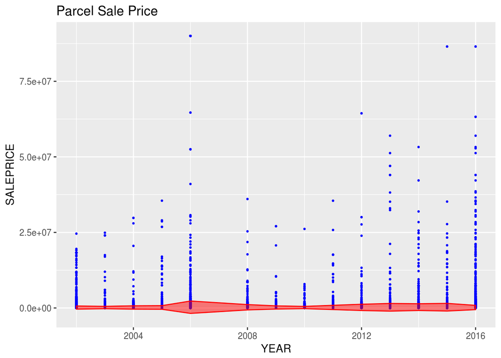

```r
ts_m<-ts_full %>% group_by(YEAR) %>%summarise(mean=mean(SALEPRICE, na.rm=T))
ts_sd<-ts_full %>% group_by(YEAR) %>%summarise(sd=sd(SALEPRICE, na.rm=T))
t_lim<-mutate(ts_m,upper=ts_m$mean+ts_sd$sd, lower=ts_m$mean-ts_sd$sd)

p2<-p + geom_ribbon(data=t_lim, aes(x=YEAR, ymin=lower, ymax=upper), inherit.aes=FALSE, colour="red", fill="red", alpha=0.5)
print(p2)
```

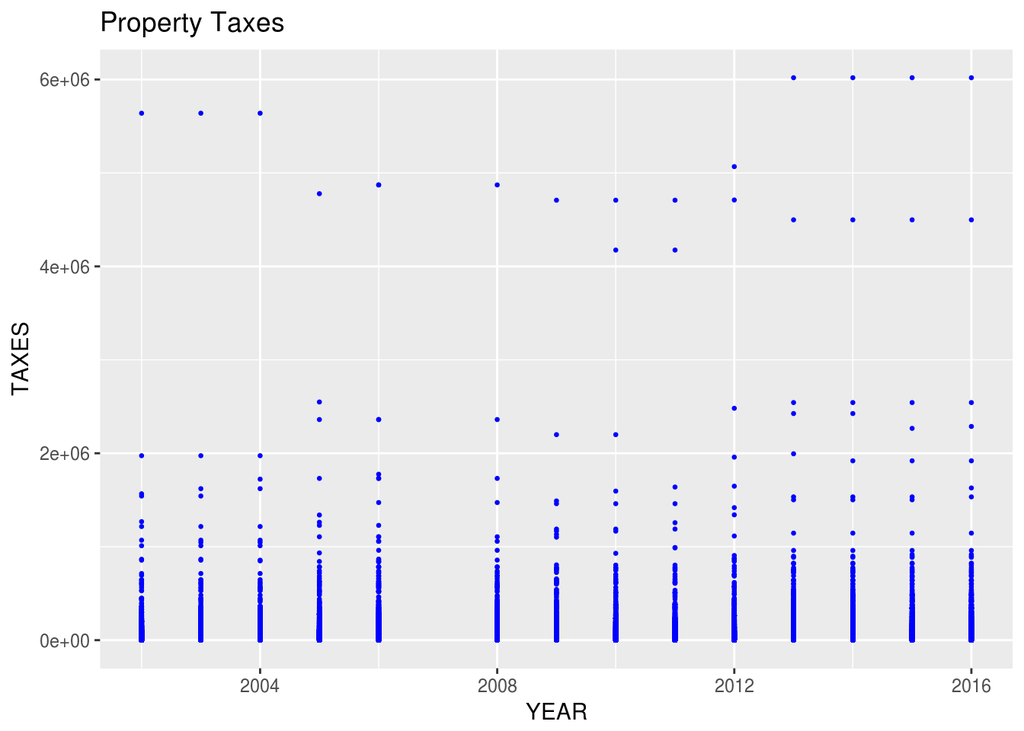

```r
p3<-ggplot(ts_full, aes(x = YEAR, y = TAXES)) +
  geom_point(colour="blue", na.rm=T,  size=0.5) + ggtitle("Property Taxes")
print(p3)
```

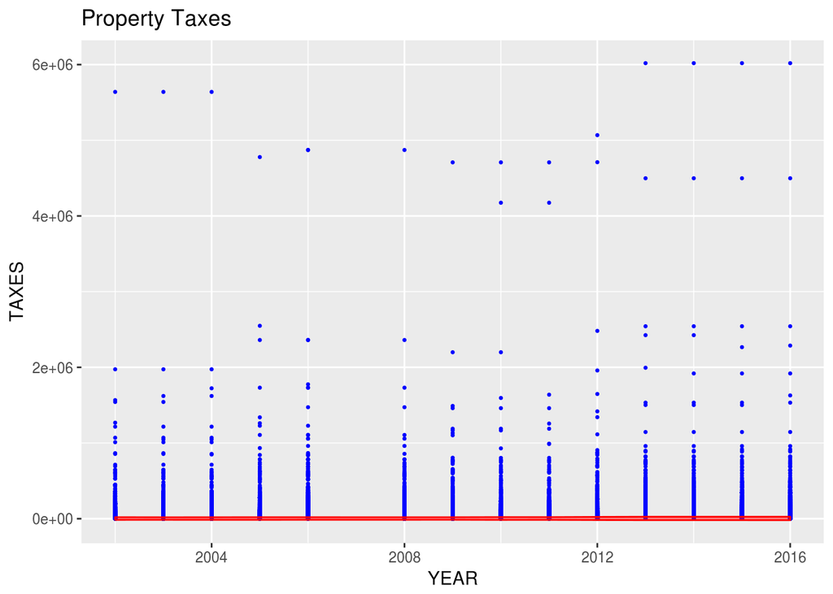

```r
ts_m<-ts_full %>% group_by(YEAR) %>%summarise(mean=mean(TAXES, na.rm=T))
ts_sd<-ts_full %>% group_by(YEAR) %>%summarise(sd=sd(TAXES, na.rm=T))
t_lim<-mutate(ts_m,upper=ts_m$mean+ts_sd$sd, lower=ts_m$mean-ts_sd$sd)

p3b<-p3 + geom_ribbon(data=t_lim, aes(x=YEAR, ymin=lower, ymax=upper), inherit.aes=FALSE, colour="red", fill="red", alpha=0.5)
print(p3b)
```

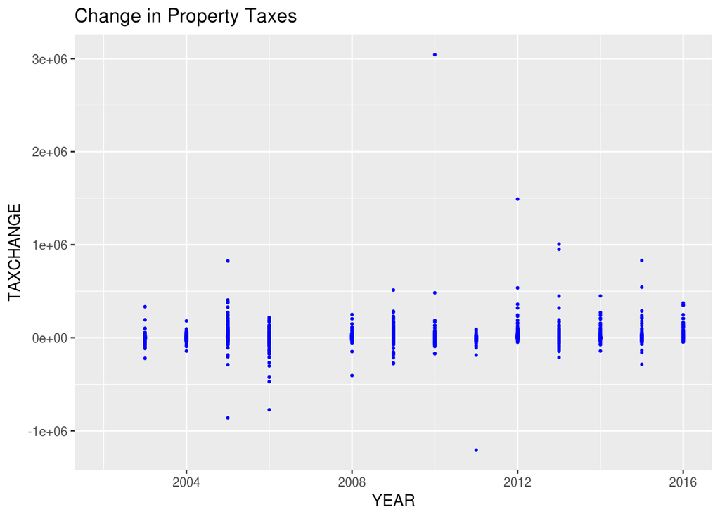

```r
p4<-ggplot(ts_full, aes(x = YEAR, y = TAXCHANGE)) +
  geom_point(colour="blue", na.rm=T,  size=0.5) + ggtitle("Change in Property Taxes")
print(p4)
```

```r
#saveRDS(ts_full,'ts_full2.RDS')
```

Now we upload the parcel shapefile and build a spatial object using the most recent parcel shapefile (2016) available. Due to computational intensity of building an adjacency matrix for a ~300,000 by ~300,000 matrix create a continuous SPDE mesh based on the centroids of the parcel polygons instead.

```r
library(sp)
library(INLA)
library(spdep)
library(rgeos)
library(raster)
library(rgdal)
library(geoR)
```

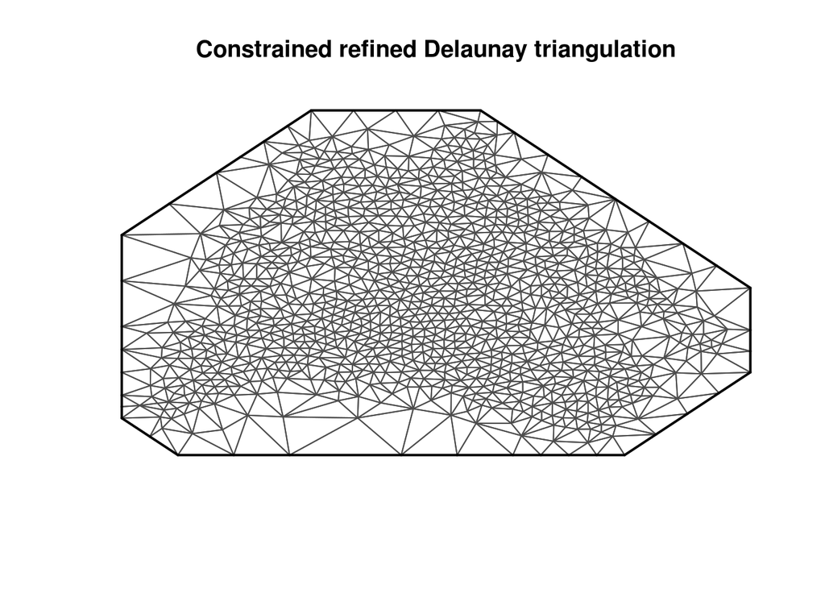

```r
library(dplyr)
library(knitr)

#parcelshape <- readRDS(paste0(wd,'/data/parcels2016.RDS'))
#
# shp<-parcelshape
# shp<-shp[ ,2] #select only the parcel id to work with
#
# saveRDS(shp,(paste0(wd,'/data/parcelshp16.RDS')))
shp<-readRDS(paste0(wd,'/data/parcelshp16.RDS'))


########################
###Create SPDE object###
########################

#find the center of each parcel in 2016
trueCentroids <- gCentroid(shp,byid=TRUE)
  # plot(shp)
  # points(trueCentroids,cex=.1, col="red")

#overlay centroids with parcels and return parcel id by centroid index
join_values <- over(trueCentroids, shp)

#join parcel id to centroid lat long
loc_id <- cbind(coordinates(trueCentroids), join_values)

#join parcel data to centroids by parcel id
d<-inner_join(loc_id,p2016_dat,by="STANPAR")

#remove duplicate records --> check this
d<-distinct(d)
d<-d[ ,c(1:3)]

#remove duplicate locations for the single year
d<-filter(d, !duplicated(x, y))

#merge each years data with the unduplicated spatial records
d02<-merge(d,ts_full[ts_full$YEAR==2002,], all.x=T)
d02<-distinct(d02)
d02$YEAR<-2002
d03<-merge(d,ts_full[ts_full$YEAR==2003,], all.x=T)
d03<-distinct(d03)
d03$YEAR<-2003
d04<-merge(d,ts_full[ts_full$YEAR==2004,], all.x=T)
d04<-distinct(d04)
d04$YEAR<-2004
d05<-merge(d,ts_full[ts_full$YEAR==2005,], all.x=T)
d05<-distinct(d05)
d05$YEAR<-2005
d06<-merge(d,ts_full[ts_full$YEAR==2006,], all.x=T)
d06<-filter(d06, !duplicated(x, y))
d06$YEAR<-2006
d07<-merge(d,ts_full[ts_full$YEAR==2007,], all.x=T)
d07<-distinct(d07)
d07$YEAR<-2007
d08<-merge(d,ts_full[ts_full$YEAR==2008,], all.x=T)
d08<-distinct(d08)
d08$YEAR<-2008
d09<-merge(d,ts_full[ts_full$YEAR==2009,], all.x=T)
d09<-distinct(d09)
d09$YEAR<-2009
d10<-merge(d,ts_full[ts_full$YEAR==2010,], all.x=T)
d10<-distinct(d10)
d10$YEAR<-2010
d11<-merge(d,ts_full[ts_full$YEAR==2011,], all.x=T)
d11<-distinct(d11)
d11$YEAR<-2011
d12<-merge(d,ts_full[ts_full$YEAR==2012,], all.x=T)
d12<-distinct(d12)
d12$YEAR<-2012
d13<-merge(d,ts_full[ts_full$YEAR==2013,], all.x=T)
d13<-distinct(d13)
d13$YEAR<-2013
d14<-merge(d,ts_full[ts_full$YEAR==2014,], all.x=T)
d14<-distinct(d14)
d14$YEAR<-2014
d15<-merge(d,ts_full[ts_full$YEAR==2015,], all.x=T)
d15<-distinct(d15)
d15$YEAR<-2015
d16<-merge(d,ts_full[ts_full$YEAR==2016,], all.x=T)
d16<-distinct(d16)
d16$YEAR<-2016

#create a full dataset of each years records at each time and space pt
dfull<-rbind(d02,d03,d04,d05,d06,d07,d08,d09,d10,d11,d12,d13,d14,d15, d16)

#coordinates(dfull) <- dfull[dfull$YEAR==2015,c(2,3)]

#d@data<-left_join(d@data,d02, by="STANPAR") #merge the spatialpts dataframe with the full time series

#create a spatialpts dataframe from lat,lon in single year


#saveRDS(d,'fullparcelshp.RDS')

######CONSIDER, if we want to allow for multiple parcel records (say for condos) to be associated with a single pt or to allow for parcels to shift from year this will need to be modified. 1. extract the centroids for each parcel data year 2. for each year remove duplicated records 3. for each year find duplicated locations with different records 4. for parcels that are members of the duplicated locations add a random value (5 decimals) to shift the pt slightly 5. repeat as needed to remove all location duplication ina  single year 6. create a set of full dataset with coords for all parcels and times

    #dups<-duplicated(d) #find duplicated coords in that single year
    #dups<-shift(dups,c(0.00001, 0.00001)
    #d2<-inner_join(loc_id,ts_full,by="STANPAR")
    #coords <- d2[ ,c(1,2)]

#create a mesh for estimation,
coords<-unique(dfull[ ,c('x','y')])
coords<-cbind(coords$x,coords$y)

coords<-cbind(dfull$x, dfull$y)
mesh<-inla.mesh.2d(loc=coords,  max.edge=1, cutoff = .01 )
p<-plot(mesh) #check projection stuff
```

```r
spde <-inla.spde2.matern(mesh=mesh, alpha=2) #pg 206

 #coords <-cbind(d$x, d$y)
 n.parcels<-length(d[,1]) #number of unique parcel locations
 n.data<-length(dfull$STANPAR)#number of space-time data pts
 n.year<-round(n.data/n.parcels)#number of time pts

  A <-inla.spde.make.A(mesh=mesh,loc=coords,
                       index = rep(1:n.parcels, times=n.year),
                       repl =rep(1:n.year, each=n.parcels))

  s.index <- inla.spde.make.index(name="spatial.field", n.spde=spde$n.spde, n.repl=n.year)

print(p)
```

Now I setup an INLA run that will estimate the relationship between spatial location and change in property taxes.

```r
dat<-dfull

#define the dependent
y<-dat$TAXCHANGE
 y[y==0]<-NA #remove zeros as they will produce INF in the data when scaling via log10
 y<-log10(y) #if not rescaled model will not converge (The Newton-Raphson optimizer did not converge, Condition `lambda < 1.0 / lambda_lim' is not TRUE), this also makes the data approx gauss distr
#create an inla data stack
  stack.d<-inla.stack(data=list(y=y), A=list(A),
                       effects=list(c(s.index, list(intercept=1))))


#define the model to estimate--> this one should be estimating a space with continous spde through space
  #nulls.mod<-y~-1 + intercept + f(spatial.field, model=spde)

#run the model
    # output<-inla(nulls.mod, data=inla.stack.data(stack.d, spde=spde), family = "gaussian",  control.fixed = list(prec.intercept = 0.1),   control.predictor = list(A=inla.stack.A(stack.d), compute=FALSE), verbose=TRUE) #for now dosn't estimate predicted values

  #saveRDS(output,file=paste0(wd,'/output/nulls.mod'))

#read the null model in and get a summary
null<-readRDS(paste0(wd,'/output/nulls.mod'))
summary(null)
```

```
##
## Call:
## c("inla(formula = nulls.mod, family = \"gaussian\", data = inla.stack.data(stack.d, ",  "    spde = spde), verbose = TRUE, control.predictor = list(A = inla.stack.A(stack.d), ",  "    compute = FALSE), control.fixed = list(prec.intercept = 0.1))" )
##
## Time used:
##  Pre-processing    Running inla Post-processing           Total
##          7.0318       1758.0969          2.5779       1767.7066
##
## Fixed effects:
##             mean      sd 0.025quant 0.5quant 0.975quant   mode kld
## intercept 2.1545 17.7012   -38.0617   2.6171    39.4448 2.9786   0
##
## Random effects:
## Name   Model
##  spatial.field   SPDE2 model
##
## Model hyperparameters:
##                                           mean     sd 0.025quant 0.5quant
## Precision for the Gaussian observations  6.809 0.0058     6.7980    6.809
## Theta1 for spatial.field                -5.106 0.0413    -5.1705   -5.112
## Theta2 for spatial.field                 1.250 0.5059     0.1224    1.312
##                                         0.975quant   mode
## Precision for the Gaussian observations      6.821  6.809
## Theta1 for spatial.field                    -5.013 -5.132
## Theta2 for spatial.field                     2.069  1.518
##
## Expected number of effective parameters(std dev): 1163.69(0.6609)
## Number of equivalent replicates : 2354.88
##
## Marginal log-Likelihood:  -1265817.17
```

```r
# #define the model to estimate--> this one should be estimating a space-time model with continous spde through space and ar1 through time
# nullst.mod<-y~-1 + intercept + f(spatial.field, model=spde, group=spatial.field.group, control.group=list(model="ar1"))
#
# #create an inla data stack
# stack.d<-inla.stack(data=list(y=y), A=list(A.est2),
#                     effects=list(c(s.index2, list(intercept=1))))
#
# #run the model
# output<-inla(nullst.mod, data=inla.stack.data(stack.d, spde=spde), family = "gaussian", control.predictor = list(A=inla.stack.A(stack.d), compute=FALSE)) #for now dosn't estimate predicted values
# saveRDS(output,file=paste0(wd,'/output/nullst.mod'))
```

We would now like to see how the spatial effect is distributed across Davidson County. We do this by projecting the estimated effects onto a spatial grid.

[figure not shown]

```r
bounds<-extent(shp) #find the min and max extents of Davidson County for grid creation

stepsize<-1/111 #should give a roughly 1km by 1km pixel grid-->check this, something is off

nxy<-round(c(diff(range(bounds@xmax, bounds@xmin)), diff(range(bounds@ymin,bounds@ymax)))/stepsize) #number of pixels

projgrid<-inla.mesh.projector(mesh, xlim=range(bounds@xmax, bounds@xmin),ylim=range(bounds@ymin,bounds@ymax),dims=nxy) #associate inla mesh with grid

xmean<-inla.mesh.project(projgrid, null$summary.random$s$mean) #associate the estimates with the grid
xsd<-inla.mesh.project(projgrid, null$summary.random$s$sd)

#combine the results with the locations in a dataframe
 test<-as.vector(xmean)
      test2<-as.vector(xsd)
      t<-cbind(projgrid$lattice$loc, test,test2)
      t<- as.data.frame(t)
      colnames(t)<-c("x","y","mean","sd")

#remove parts of the plot outside the county border
library(lattice)
library(sp)
library(rgeos)
library(maptools)
      coordinates(t)<-cbind(t$x,t$y)
      proj4string(t)<-proj4string(shp)
      tclip<-t[shp,]
      plot(tclip)
```

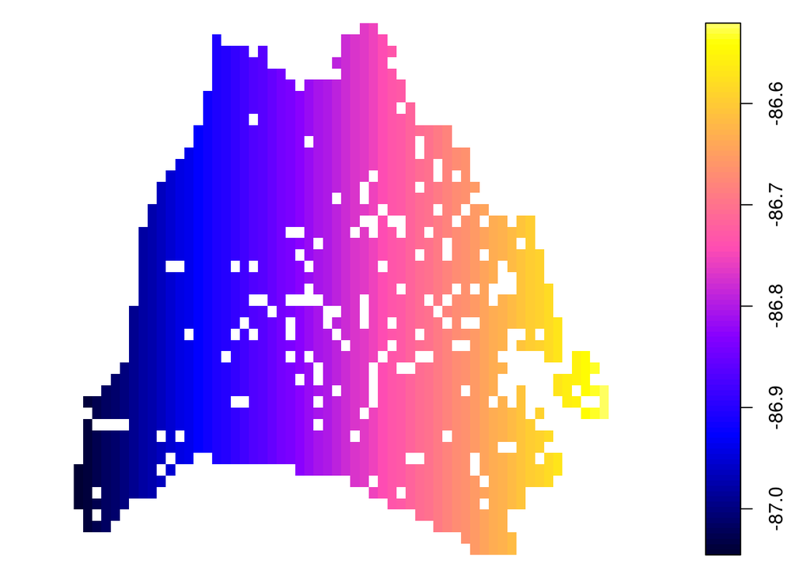

```r
      gridded(tclip)<-TRUE
      plot(tclip)
```

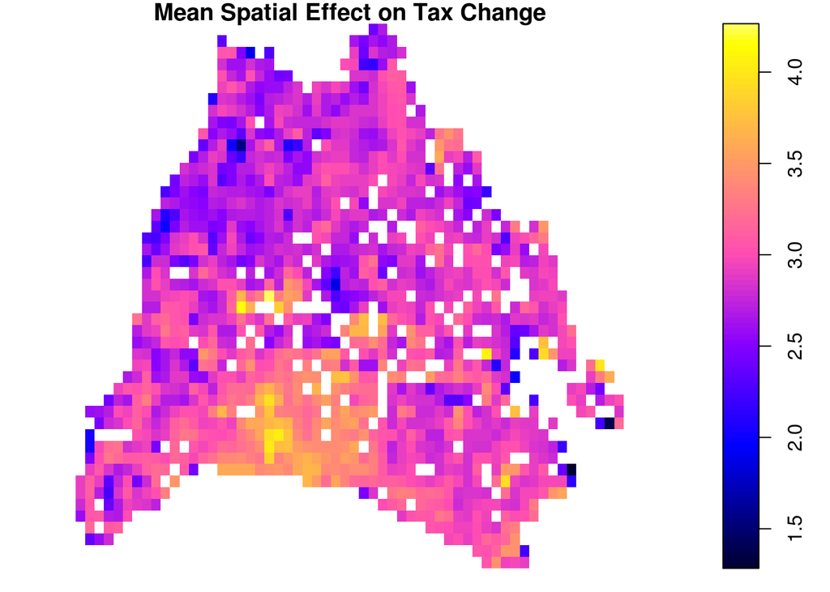

```r
#plot the spatial effect estimates
      plot(tclip[ ,"mean"], main="Mean Spatial Effect on Tax Change")
```

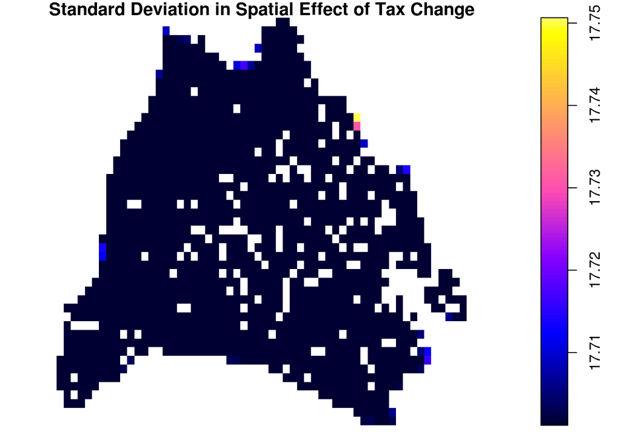

```r
      plot(tclip[ ,"sd"], main="Standard Deviation in Spatial Effect of Tax Change")
```

```r
# dat<-dfull
#
# # dat<-dat[dat$YEAR>2002,] #remove
# # dat<-dat[dat$YEAR<2010]
# dat$SALEPRICE[dat$SALEPRICE==0]<-NA
# dat$SALEPRICE<-log10(dat$SALEPRICE)
# #define the dependent
# y<-dat$TAXCHANGE
#  y[y==0]<-NA #remove zeros as they will produce INF in the data when scaling via log10
#  y<-log10(y)
#
#
# #create an inla data stack
#   stack.d2<-inla.stack(data=list(y=y), A=list(A, 1),
#                       effects=list(c(s.index, list(intercept=1)), list(dat[ ,c(4,5,7,8,9)])))
#
#
# #define the model to estimate--> this one should be estimating a space-time model with continous spde through space and ar1 through time
#   sales.mod<-y~-1 + intercept + SALEPRICE + f(spatial.field, model=spde)
#
# #run the model
#      output<-inla(sales.mod, data=inla.stack.data(stack.d2, spde=spde), family = "gaussian",  control.fixed = list(prec.intercept = 0.1),   control.predictor = list(A=inla.stack.A(stack.d2), compute=FALSE), verbose=T) #for now dosn't estimate predicted values
#
#   saveRDS(output,file=paste0(wd,'/output/salestax.mod'))

#read the null model in and get a summary
salestax<-readRDS(paste0(wd,'/output/salestax.mod'))
summary(salestax)
```

```
##
## Call:
## c("inla(formula = sales.mod, family = \"gaussian\", data = inla.stack.data(stack.d2, ",  "    spde = spde), verbose = T, control.predictor = list(A = inla.stack.A(stack.d2), ",  "    compute = FALSE), control.fixed = list(prec.intercept = 0.1))" )
##
## Time used:
##  Pre-processing    Running inla Post-processing           Total
##         12.1761      22179.2352          0.5113      22191.9225
##
## Fixed effects:
##             mean     sd 0.025quant 0.5quant 0.975quant   mode kld
## intercept 1.9735 0.1703     1.6052   1.9833     2.2859 2.0007   0
## SALEPRICE 0.0367 0.0005     0.0356   0.0367     0.0377 0.0367   0
##
## Random effects:
## Name   Model
##  spatial.field   SPDE2 model
##
## Model hyperparameters:
##                                           mean     sd 0.025quant 0.5quant
## Precision for the Gaussian observations  3.845 0.0077      3.830    3.845
## Theta1 for spatial.field                -4.715 0.0337     -4.783   -4.715
## Theta2 for spatial.field                 3.671 0.1360      3.396    3.675
##                                         0.975quant   mode
## Precision for the Gaussian observations      3.861  3.844
## Theta1 for spatial.field                    -4.650 -4.713
## Theta2 for spatial.field                     3.930  3.685
##
## Expected number of effective parameters(std dev): 990.00(2.803)
## Number of equivalent replicates : 556.79
##
## Marginal log-Likelihood:  -420405.82
```

```r
###################################
#
# #define the model to estimate--> this one should be estimating a space-time model with continous spde through space and ar1 through time
#   sales2.mod<-y~-1 + intercept + f(SALEPRICE, model=spde)
#
# #run the model
#      output<-inla(sales2.mod, data=inla.stack.data(stack.d2, spde=spde), family = "gaussian",  control.fixed = list(prec.intercept = 0.1),   control.predictor = list(A=inla.stack.A(stack.d2), compute=FALSE)) #for now dosn't estimate predicted values
#
#   saveRDS(output,file=paste0(wd,'/output/sales2.mod'))

#read the null model in and get a summary
sale2s<-readRDS(paste0(wd,'/output/sales2.mod'))
summary(sale2s)
```

[output not shown]

[figure not shown]

```r
#############################

xmean<-inla.mesh.project(projgrid, sale2s$summary.random$s$mean) #associate the estimates with the grid
xsd<-inla.mesh.project(projgrid, sale2s$summary.random$s$sd)

#combine the results with the locations in a dataframe
 test<-as.vector(xmean)
      test2<-as.vector(xsd)
      t2<-cbind(projgrid$lattice$loc, test,test2)
      t2<- as.data.frame(t2)
      colnames(t2)<-c("x","y","mean","sd")

#remove parts of the plot outside the county border
library(lattice)
library(sp)
library(rgeos)
library(maptools)

      coordinates(t2)<-cbind(t2$x,t2$y)
      proj4string(t2)<-proj4string(shp)
      tclip2<-t2[shp,]
      plot(tclip2)
```

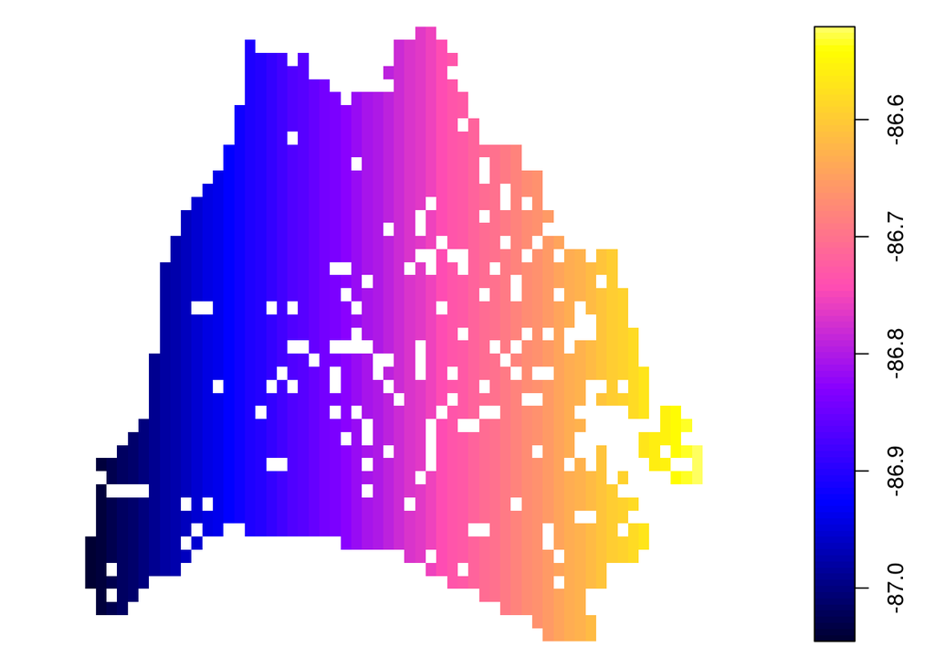

```r
      gridded(tclip2)<-TRUE
      plot(tclip2)
```

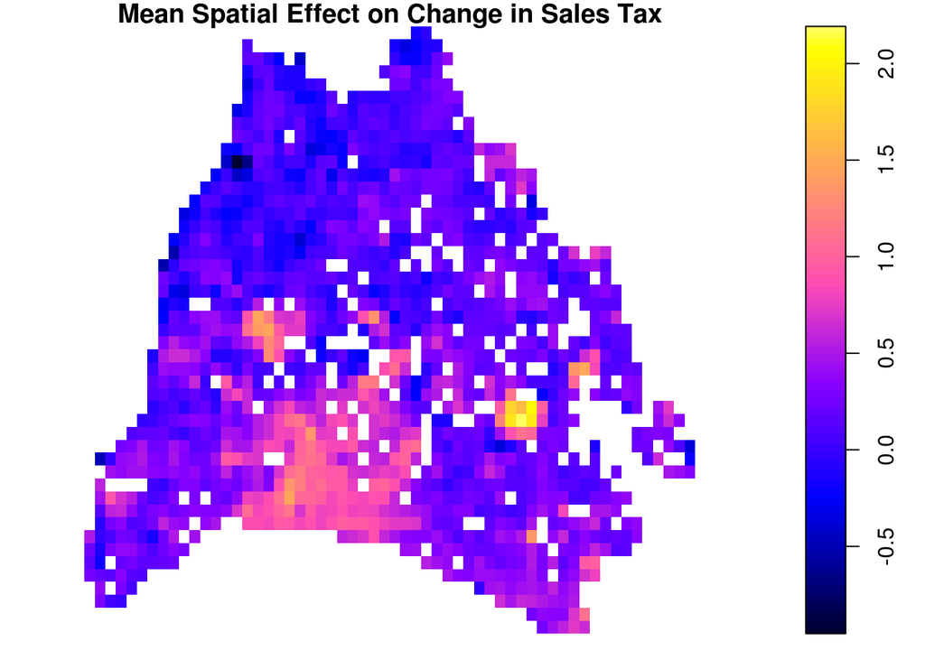

```r
#plot the spatial effect estimates
      plot(tclip2[ ,"mean"], main="Mean Spatial Effect on Change in Sales Tax")
```

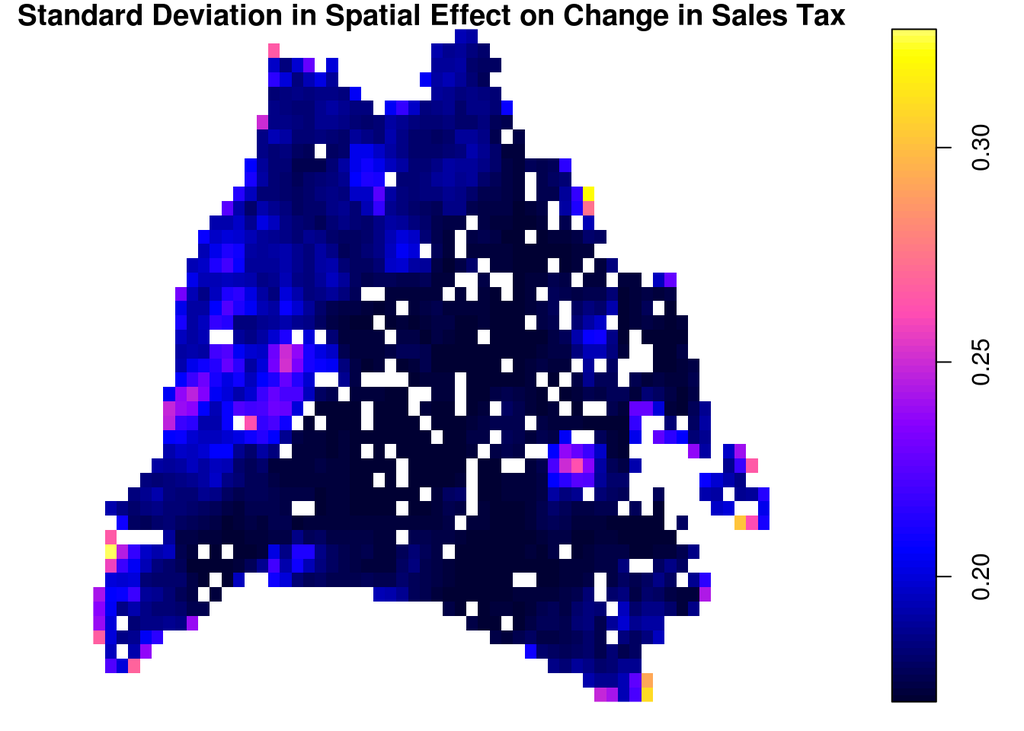

```r
      plot(tclip2[ ,"sd"], main="Standard Deviation in Spatial Effect on Change in Sales Tax")
```

Now we are interested in seeing how this relationship changes between time periods pre and post 2010 (flood year). We first estimate a model for all time prior to 2010 (2003-2009).

```r
#  dat<-dfull
# dat<-dat[dat$YEAR>2002,]
# dat<-dat[dat$YEAR<2010,] #subset to data prior to 2010
#
# #scale the explanatory var
# dat$SALEPRICE[dat$SALEPRICE==0]<-NA
# dat$SALEPRICE<-log10(dat$SALEPRICE)
#
# #define the dependent
# y<-dat$TAXES
#  y[y==0]<-NA #remove zeros as they will produce INF in the data when scaling via log10
#  y<-log10(y)
#
# #create a mesh for estimation of the subset
# coords<-unique(dat[ ,c('x','y')])
# coords<-cbind(coords$x,coords$y)
#
# coords<-cbind(dat$x, dat$y)
# mesh<-inla.mesh.2d(loc=coords,  max.edge=1, cutoff = .01 )
# plot(mesh) #check projection stuff
# spde <-inla.spde2.matern(mesh=mesh, alpha=2) #pg 206
#
#  #coords <-cbind(d$x, d$y)
#  n.parcels<-length(dat[,1]) #number of unique parcel locations
#  n.data<-length(dat$STANPAR)#number of space-time data pts
#  n.year<-round(n.data/n.parcels)#number of time pts
#
#   A <-inla.spde.make.A(mesh=mesh,loc=coords,
#                        index = rep(1:n.parcels, times=n.year),
#                        repl =rep(1:n.year, each=n.parcels))
#
#   s.index <- inla.spde.make.index(name="spatial.field", n.spde=spde$n.spde, n.repl=n.year)
#
# #create an inla data stack
#   stack.d3<-inla.stack(data=list(y=y), A=list(A, 1),
#                       effects=list(c(s.index, list(intercept=1)), list(dat[ ,c(4,5,8,9)])))
#
#
# #define the model to estimate
#   sales_pre.mod<-y~-1 + intercept + SALEPRICE + f(YEAR, model="iid") + f(spatial.field, model=spde)
#
# #run the model
#      output<-inla(sales_pre.mod, data=inla.stack.data(stack.d3, spde=spde), family = "gaussian",  control.fixed = list(prec.intercept = 0.1),   control.predictor = list(A=inla.stack.A(stack.d3), compute=FALSE)) #for now dosn't estimate predicted values
#
#   saveRDS(output,file=paste0(wd,'/output/sales_pre2.mod'))

#read the null model in and get a summary
sales_pre<-readRDS(paste0(wd,'/output/sales_pre.mod'))
summary(sales_pre)
```

```
##
## Call:
## c("inla(formula = sales_pre.mod, family = \"gaussian\", data = inla.stack.data(stack.d3, ",  "    spde = spde), control.predictor = list(A = inla.stack.A(stack.d3), ",  "    compute = FALSE), control.fixed = list(prec.intercept = 0.1))" )
##
## Time used:
##  Pre-processing    Running inla Post-processing           Total
##          6.0032       2167.9222          0.2204       2174.1458
##
## Fixed effects:
##             mean     sd 0.025quant 0.5quant 0.975quant   mode kld
## intercept 2.1025 4.4686    -8.0355   2.1580    11.8652 2.1958   0
## SALEPRICE 0.0028 0.0002     0.0024   0.0028     0.0033 0.0028   0
##
## Random effects:
## Name   Model
##  spatial.field   SPDE2 model
##
## Model hyperparameters:
##                                           mean     sd 0.025quant 0.5quant
## Precision for the Gaussian observations  8.811 0.0118      8.789    8.811
## Theta1 for spatial.field                -4.813 0.0365     -4.872   -4.817
## Theta2 for spatial.field                 2.212 0.3492      1.435    2.254
##                                         0.975quant   mode
## Precision for the Gaussian observations      8.835  8.811
## Theta1 for spatial.field                    -4.732 -4.833
## Theta2 for spatial.field                     2.781  2.395
##
## Expected number of effective parameters(std dev): 1154.54(1.089)
## Number of equivalent replicates : 1020.72
##
## Marginal log-Likelihood:  -429985.24
```

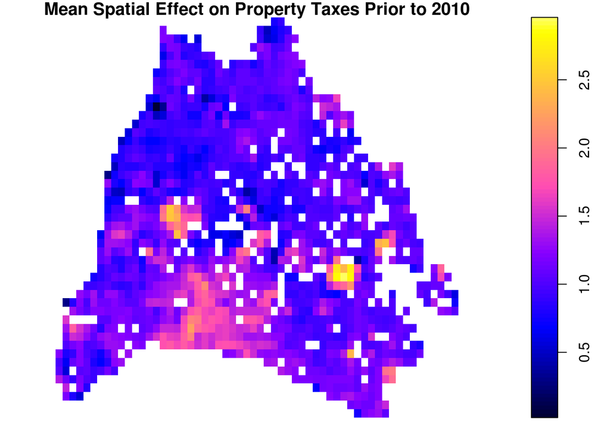

```r
#############################

xmean<-inla.mesh.project(projgrid, sales_pre$summary.random$spatial.field$mean) #associate the estimates with the grid
xsd<-inla.mesh.project(projgrid, sales_pre$summary.random$s$sd)

#combine the results with the locations in a dataframe
 test<-as.vector(xmean)
      test2<-as.vector(xsd)
      t2<-cbind(projgrid$lattice$loc, test,test2)
      t2<- as.data.frame(t2)
      colnames(t2)<-c("x","y","mean","sd")

#remove parts of the plot outside the county border
library(lattice)
library(sp)
library(rgeos)
library(maptools)

      coordinates(t2)<-cbind(t2$x,t2$y)
      proj4string(t2)<-proj4string(shp)
      tclip2<-t2[shp,]
      # plot(tclip2)
       gridded(tclip2)<-TRUE
      # plot(tclip2)


#plot the spatial effect estimates
      fp<-shapefile(paste0(wd,'/data/OnehunderedyrFloodplain.shp'))
      #fp<-spTransform(fp,proj4string(difference))
       plot(tclip2[ ,"mean"], main="Mean Spatial Effect on Property Taxes Prior to 2010")
      plot(fp,border="lightblue",add=TRUE)
```

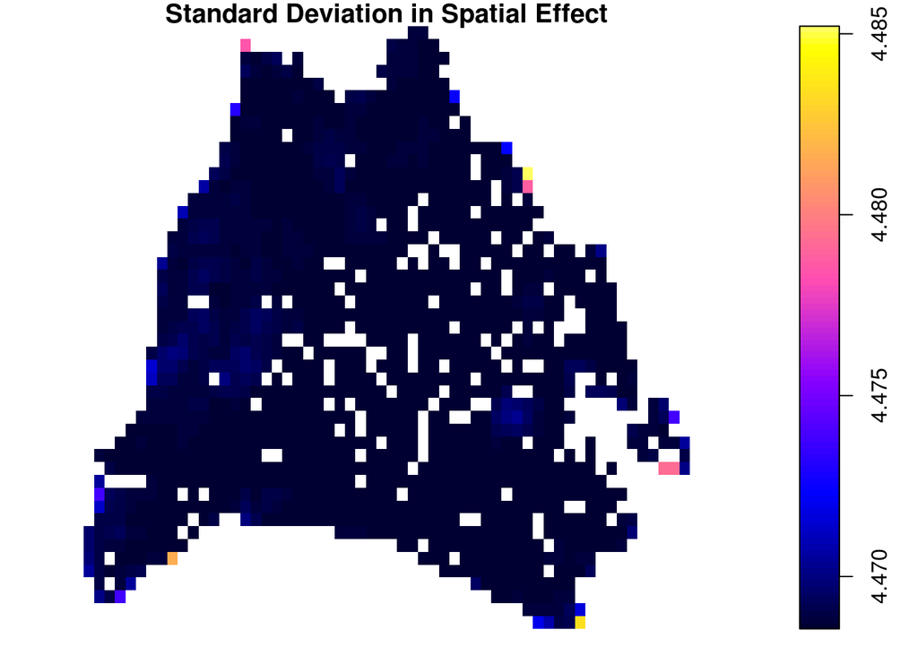

```r
      plot(tclip2[ ,"sd"], main="Standard Deviation in Spatial Effect")
```

Now we estimate a model for all time post 2010 (2011-2016).

```r
# dat<-dfull
# dat<-dat[dat$YEAR>2010,] #subset to data prior to 2010
#
# #scale the explanatory var
# dat$SALEPRICE[dat$SALEPRICE==0]<-NA
# dat$SALEPRICE<-log10(dat$SALEPRICE)
#
# #define the dependent
# y<-dat$TAXES
#  y[y==0]<-NA #remove zeros as they will produce INF in the data when scaling via log10
#  y<-log10(y)
#
# #create a mesh for estimation of the subset
# coords<-unique(dat[ ,c('x','y')])
# coords<-cbind(coords$x,coords$y)
#
# coords<-cbind(dat$x, dat$y)
# mesh<-inla.mesh.2d(loc=coords,  max.edge=1, cutoff = .01 )
# plot(mesh) #check projection stuff
# spde <-inla.spde2.matern(mesh=mesh, alpha=2) #pg 206
#
#  #coords <-cbind(d$x, d$y)
#  n.parcels<-length(dat[,1]) #number of unique parcel locations
#  n.data<-length(dat$STANPAR)#number of space-time data pts
#  n.year<-round(n.data/n.parcels)#number of time pts
#
#   A <-inla.spde.make.A(mesh=mesh,loc=coords,
#                        index = rep(1:n.parcels, times=n.year),
#                        repl =rep(1:n.year, each=n.parcels))
#
#   s.index <- inla.spde.make.index(name="spatial.field", n.spde=spde$n.spde, n.repl=n.year)
#
# #create an inla data stack
#   stack.d4<-inla.stack(data=list(y=y), A=list(A, 1),
#                       effects=list(c(s.index, list(intercept=1)), list(dat[ ,c(4,5,8,9)])))
#
#
# #define the model to estimate--> this one should be estimating a space-time model with continous spde through space and ar1 through time
#   sales_post.mod<-y~-1 + intercept + SALEPRICE +f(YEAR, model="iid")+ f(spatial.field, model=spde)
#
# #run the model
#      output<-inla(sales_post.mod, data=inla.stack.data(stack.d4, spde=spde), family = "gaussian",  control.fixed = list(prec.intercept = 0.1),   control.predictor = list(A=inla.stack.A(stack.d4), compute=FALSE)) #for now dosn't estimate predicted values
#
#   saveRDS(output,file=paste0(wd,'/output/sales_post2.mod'))

#read the null model in and get a summary
sales_post<-readRDS(paste0(wd,'/output/sales_post2.mod'))
summary(sales_post)
```

```
##
## Call:
## c("inla(formula = sales_post.mod, family = \"gaussian\", data = inla.stack.data(stack.d4, ",  "    spde = spde), control.predictor = list(A = inla.stack.A(stack.d4), ",  "    compute = FALSE), control.fixed = list(prec.intercept = 0.1))" )
##
## Time used:
##  Pre-processing    Running inla Post-processing           Total
##          7.7549       3443.8332          0.3841       3451.9722
##
## Fixed effects:
##             mean     sd 0.025quant 0.5quant 0.975quant   mode kld
## intercept 2.5576 1.0927      0.290   2.5713     4.7626 2.5983   0
## SALEPRICE 0.0024 0.0002      0.002   0.0024     0.0029 0.0024   0
##
## Random effects:
## Name   Model
##  YEAR   IID model
## spatial.field   SPDE2 model
##
## Model hyperparameters:
##                                             mean        sd 0.025quant
## Precision for the Gaussian observations    9.465    0.0127      9.440
## Precision for YEAR                      4752.044 2501.9648   1239.548
## Theta1 for spatial.field                  -4.843    0.0283     -4.894
## Theta2 for spatial.field                   2.889    0.1407      2.593
##                                         0.5quant 0.975quant     mode
## Precision for the Gaussian observations    9.465      9.490    9.465
## Precision for YEAR                      4335.253  10732.126 3229.327
## Theta1 for spatial.field                  -4.844     -4.783   -4.849
## Theta2 for spatial.field                   2.897      3.145    2.922
##
## Expected number of effective parameters(std dev): 1181.37(0.8751)
## Number of equivalent replicates : 998.48
##
## Marginal log-Likelihood:  -407661.24
```

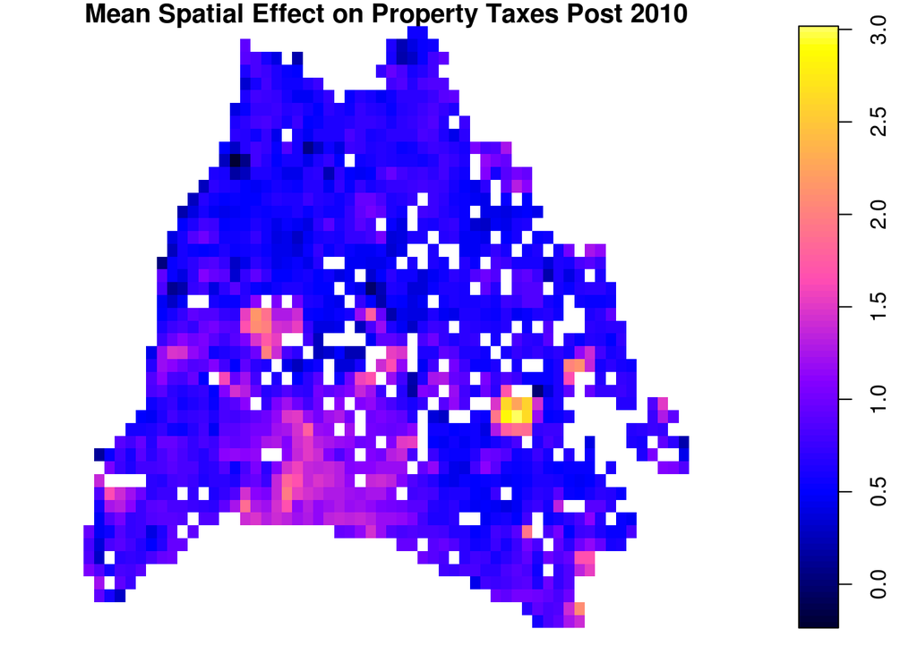

```r
#############################

xmean<-inla.mesh.project(projgrid, sales_post$summary.random$spatial.field$mean) #associate the estimates with the grid
xsd<-inla.mesh.project(projgrid, sales_post$summary.random$s$sd)

#combine the results with the locations in a dataframe
 test<-as.vector(xmean)
      test2<-as.vector(xsd)
      t2<-cbind(projgrid$lattice$loc, test,test2)
      t2<- as.data.frame(t2)
      colnames(t2)<-c("x","y","mean","sd")

#remove parts of the plot outside the county border
library(lattice)
library(sp)
library(rgeos)
library(maptools)

      coordinates(t2)<-cbind(t2$x,t2$y)
      proj4string(t2)<-proj4string(shp)
      tclip3<-t2[shp,]
     # plot(tclip2)
      gridded(tclip3)<-TRUE
     # plot(tclip2)


#plot the spatial effect estimates
      # fp<-shapefile(paste0(wd,'/data/OnehunderedyrFloodplain.shp'))
      #fp<-spTransform(fp,proj4string(difference))
      plot(tclip3[ ,"mean"], main="Mean Spatial Effect on Property Taxes Post 2010")
      plot(fp,border="lightblue",add=TRUE)
```

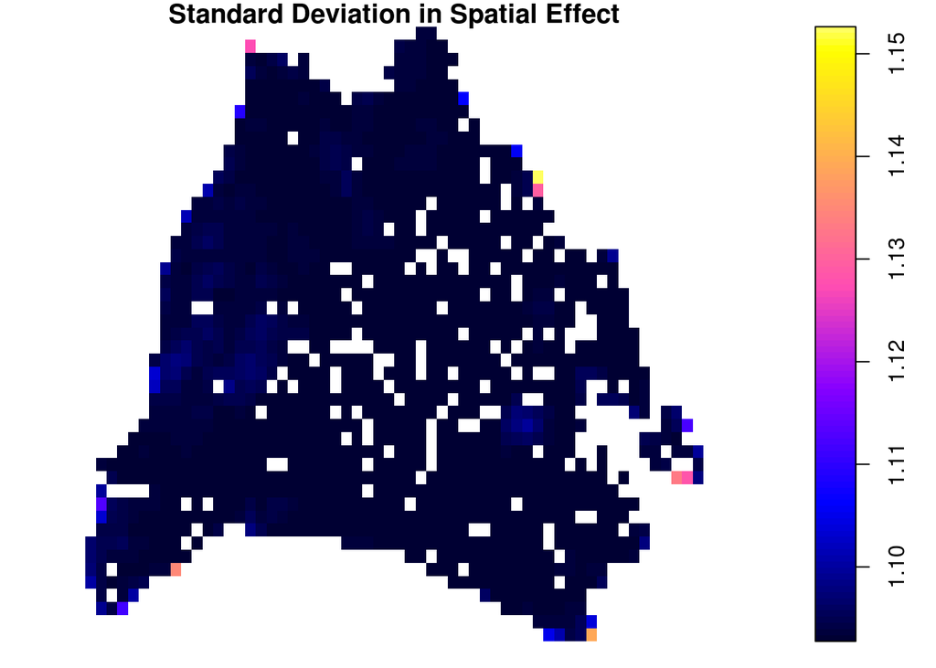

```r
      plot(tclip3[ ,"sd"], main="Standard Deviation in Spatial Effect")
```

Now we would like to see the difference in the spatial effects

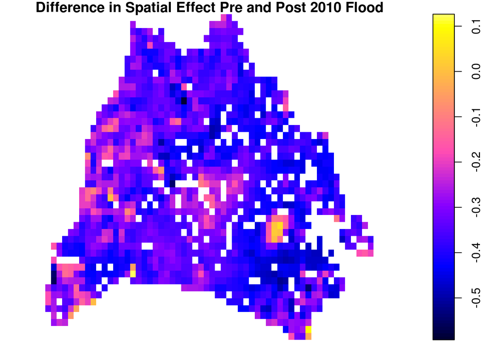

```r
library(raster)
library(lattice)
pre<-tclip2
post<-tclip3

delta<-over(pre,post)
pre@data <- cbind(pre@data, delta)
pre$delta<-pre[[7]]-pre[[3]]

difference<-pre
difference$delta[difference$delta>0.3]<-NA
# fp<-shapefile(paste0(wd,'/data/OnehunderedyrFloodplain.shp'))
#fp<-spTransform(fp,proj4string(difference))
#proj4string(fp)

plot(difference [ ,"delta"], main="Difference in Spatial Effect Pre and Post 2010 Flood")
plot(fp,border="lightblue",add=TRUE)
```